# Correlation Analysis

#### This chapter contains articles for computing and visualizing correlation analyses in R. Recall that, correlation analysis is used to investigate the association between two or more variables. A simple example, is to evaluate whether there is a link between maternal age and child’s weight at birth.

### 1. Correlation Test Between **Two** Variables

- Brief outline:
  - What is correlation test?
  - Methods for correlation analyses
  - **Correlation formula**
    - **Pearson** correlation formula
    - **Spearman** correlation formula
    - **Kendall** correlation formula
  - Compute **correlation** in R
  - R functions
  - Import your data into R
  - Visualize your data using scatter plots
  - Preliminary test to check the test **assumptions**
  - **Pearson correlation test**
  - **Kendall rank correlation test**
  - **Spearman rank correlation coefficient**
  - Interpret **correlation coefficient**

### 2. Correlation Matrix: Analyze, Format and Visualize

- Correlation matrix is used to analyze the correlation between multiple variables at the same time.
- Brief outline:
  - What is correlation matrix?
  - Compute correlation matrix in R
  - R functions
  - Compute correlation matrix
  - Correlation matrix with significance levels (p-value)
  - A simple function to format the correlation matrix
  - Visualize correlation matrix
    - Use `symnum{stats}` function: Symbolic number coding
    - Use `corrplot{corrplot}` function: Draw a correlogram
    - Use `chart.Correlation{PerformanceAnalytics}` function: Draw scatter plots
    - Use `heatmap{stats}` function

### 3. Visualize Correlation Matrix using Correlogram

- Correlogram
  - is a graph of correlation matrix.
  - is useful to highlight the most correlated variables in a data table.
- In this plot, correlation coefficients are colored according to the value.
- Correlation matrix can be also reordered according to the degree of association between variables.
- Brief outline:
  - Install R corrplot package
  - Data for correlation analysis
  - Computing correlation matrix
  - Correlogram : Visualizing the correlation matrix
  - Visualization methods
  - Types of correlogram layout
  - Reordering the correlation matrix
  - Changing the color of the correlogram
  - Changing the color and the rotation of text labels
  - Combining correlogram with the significance test
  - Customize the correlogram

```r
library(corrplot)
library(RColorBrewer)

( M <-cor(mtcars) )
```

```
##             mpg        cyl       disp         hp        drat         wt
## mpg   1.0000000 -0.8521620 -0.8475514 -0.7761684  0.68117191 -0.8676594
## cyl  -0.8521620  1.0000000  0.9020329  0.8324475 -0.69993811  0.7824958
## disp -0.8475514  0.9020329  1.0000000  0.7909486 -0.71021393  0.8879799
## hp   -0.7761684  0.8324475  0.7909486  1.0000000 -0.44875912  0.6587479
## drat  0.6811719 -0.6999381 -0.7102139 -0.4487591  1.00000000 -0.7124406
## wt   -0.8676594  0.7824958  0.8879799  0.6587479 -0.71244065  1.0000000
## qsec  0.4186840 -0.5912421 -0.4336979 -0.7082234  0.09120476 -0.1747159
## vs    0.6640389 -0.8108118 -0.7104159 -0.7230967  0.44027846 -0.5549157
## am    0.5998324 -0.5226070 -0.5912270 -0.2432043  0.71271113 -0.6924953
## gear  0.4802848 -0.4926866 -0.5555692 -0.1257043  0.69961013 -0.5832870
## carb -0.5509251  0.5269883  0.3949769  0.7498125 -0.09078980  0.4276059
##             qsec         vs          am       gear        carb
## mpg   0.41868403  0.6640389  0.59983243  0.4802848 -0.55092507
## cyl  -0.59124207 -0.8108118 -0.52260705 -0.4926866  0.52698829
## disp -0.43369788 -0.7104159 -0.59122704 -0.5555692  0.39497686
## hp   -0.70822339 -0.7230967 -0.24320426 -0.1257043  0.74981247
## drat  0.09120476  0.4402785  0.71271113  0.6996101 -0.09078980
## wt   -0.17471588 -0.5549157 -0.69249526 -0.5832870  0.42760594
## qsec  1.00000000  0.7445354 -0.22986086 -0.2126822 -0.65624923
## vs    0.74453544  1.0000000  0.16834512  0.2060233 -0.56960714
## am   -0.22986086  0.1683451  1.00000000  0.7940588  0.05753435
## gear -0.21268223  0.2060233  0.79405876  1.0000000  0.27407284
## carb -0.65624923 -0.5696071  0.05753435  0.2740728  1.00000000
```

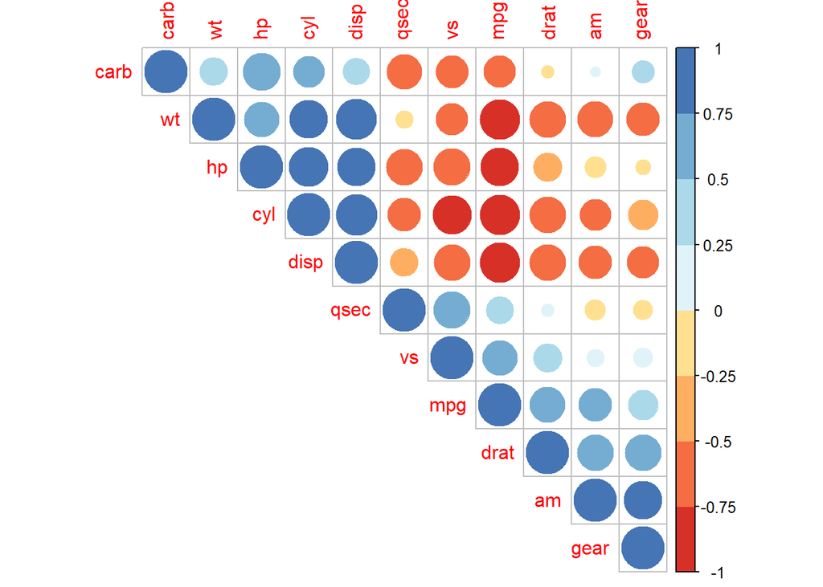

```r
corrplot(M, type="upper", order="hclust", col=brewer.pal(n=8, name="RdYlBu"))
```

### 4. Elegant Correlation Table using xtable R Package

- The aim of this article is to show you how to get the lower and the upper triangular part of a correlation matrix.
- We will use also `{xtable}` R package to display a nice correlation table.
- Brief outline:
  - Correlation matrix analysis
  - Lower and upper triangular part of a correlation matrix
  - Use `{xtable}` R package to display nice correlation table in html format
  - Combine matrix of correlation coefficients and significance levels